# General Linear Models: Model Fit and Diagnostics

## Introduction

- We are back in Savanna Central, helping a bakery and a café understand daily sales.
- Last lecture: fitting and interpreting regression models.
- This lecture: checking whether those models tell a reasonable story.

## R Set Up

## `R` Set Up

```r
library(tidyverse)
library(ssstats)
library(broom)
bakery_sales <- read_csv("https://raw.githubusercontent.com/samanthaseals/SDSI/refs/heads/main/files/data/lectures/7-5-bakery_sales.csv")
cafe_sales <- read_csv("https://raw.githubusercontent.com/samanthaseals/SDSI/refs/heads/main/files/data/lectures/7-6-cafe_sales.csv")
```

## General Linear Model

$$y_i = \beta_0 + \beta_1 x_{i1} + \cdots + \beta_k x_{ik} + \varepsilon_i$$

- $\varepsilon_i$ is the unobserved error around the population response surface.
- The fitted residual is

$$e_i = y_i - \hat{y}_i.$$

## Examples 3 and 4

- Recall our models examining bakery and cafe sales,

```r
m3 <- glm(sales_dollars ~ advertising_dollars + foot_traffic + temperature_c + discount_percent,
          data = bakery_sales)

m4 <- glm(sales_dollars ~ window_display_hours + music_volume_db + temperature_c + foot_traffic + advertising_dollars,
          data = cafe_sales)
```

## Model Fit and Diagnostics

- We will assess:
  - Overall model fit.
  - Observations with unusually large residuals.
  - Observations that strongly affect the fitted model.
  - Overlapping information among explanatory variables.

## Model Fit: $R^2$

- $R^2$ is the proportion of observed variation in sales explained by the model.

$$R^2 = \frac{\text{SSReg}}{\text{SSTot}} = 1 - \frac{\text{SSE}}{\text{SSTot}}$$

- For ordinary least squares with an intercept, $R^2 \in [0,1]$.
  - A larger value means more of the observed variation is explained.
  - It does *not* establish causation or guarantee good predictions.

## Model Fit: Adjusted $R^2$

- Adding predictors cannot decrease ordinary $R^2$ when the models use the same observations.
- Even an unhelpful variable can increase $R^2$ a little!

$$R^2_{\text{adj}} = 1 - \frac{n-1}{n-k-1}(1-R^2)$$

- where
  - $n$: number of observations,
  - $k$: number of predictor terms (*excludes* the intercept).

## Model Fit: $R^2$ (`R`)

- We use `r_squared()` from `library(ssstats)` to assess explained variation.

```r
model_name |> r_squared()
```

[output not shown]

- Interpret the values in terms of variation in daily bakery sales.

## Example 3

- Let’s check the $R^2$ for the bakery sales,

```r
m3 |> r_squared()
```

```
[1] 0.8821
```

## Model Fit: Adjusted $R^2$

- What happens if we have a low $R^2$?
- Questions to ask:
  - Do the residual plots reveal curvature or changing spread?
  - Are unusual days affecting the fit?
  - Is sales variation simply difficult to explain?
  - Are important variables missing, such as festivals or large catering orders?
- Low $R^2$ does not, by itself, imply that the model is useless.

## Model Fit: AIC and BIC

- AIC and BIC balance model fit against model complexity.
- We will not derive the likelihood formulas here.
- Their penalties are:
  - AIC: $2p$.
  - BIC: $p\log(n)$.
- $p$ counts estimated likelihood parameters.
  - For a normal linear model, this includes regression coefficients and the error variance.

## Comparing Models Fairly

- Lower AIC or BIC is preferred among the candidate models.
- Compare models fitted to the **same response and the same observations**.
- Compare bakery models with bakery models, and café models with café models.
- Do not compare a bakery AIC with a café AIC to decide which business has a “better model.”
- AIC and BIC can favor different models.

## Example: The Café Owner’s Question

```r
cafe_full |> tidy()
```

[output not shown]

## Model Fit: AIC and BIC (`R`)

```r
AIC(cafe_full, cafe_core, cafe_traffic)
```

[output not shown]

```r
BIC(cafe_full, cafe_core, cafe_traffic)
```

[output not shown]

## Model Fit: Putting It Together

```r
model_comparison <- list(
  Full = cafe_full, Core = cafe_core, Traffic = cafe_traffic
) |>
  imap_dfr(function(model, label) {
    glance(model) |>
      transmute(model = label, r_squared = r.squared,
                adjusted_r_squared = adj.r.squared, AIC, BIC)
  })
```

[output not shown]

```r
knitr::kable(model_comparison, digits = 3)
```

[output not shown]

## Outliers

- A regression outlier has an unusually large residual.
- For the bakery: sales are unusually high or low **given the predictors**.
- A high-sales day is not necessarily an outlier if the model predicts high sales.
- Unusual predictor values concern leverage, which we will discuss next.

## Standardized Residuals

$$e_{i,\text{std}} = \frac{e_i}{\sqrt{\text{MSE}(1-h_i)}}$$

- Standardization accounts for the residual scale and observation leverage.
- Screening rules used in this lecture:
  - $|e_{i,\text{std}}| > 2.5$: suspected outlier.
  - $|e_{i,\text{std}}| > 3$: more extreme residual.
- These are flags for investigation, not automatic deletion rules.

## Outliers (`R`)

```r
bakery_diagnostics <- bakery_sales |>
  mutate(day_id = row_number(),
         standardized_residual = rstandard(bakery_model),
         outlier = if_else(abs(standardized_residual) > 2.5,
                           "Suspected", "Not Suspected"))
```

[output not shown]

```r
bakery_diagnostics |> count(outlier)
```

[output not shown]

## Looking at Flagged Days

```r
bakery_diagnostics |> filter(outlier == "Suspected")
```

[output not shown]

- Ask the owner what happened on those days.
- Was there a large catering order? A festival? A recording error?
- A valid unusual day can tell us something important about the business.

## Outliers Depend on the Model

```r
cafe_diagnostics <- cafe_sales |>
  mutate(day_id = row_number(),
         outlier_full = abs(rstandard(cafe_full)) > 2.5,
         outlier_core = abs(rstandard(cafe_core)) > 2.5,
         outlier_traffic = abs(rstandard(cafe_traffic)) > 2.5)
```

[output not shown]

```r
cafe_diagnostics |> count(outlier_full, outlier_core, outlier_traffic)
```

[output not shown]

- A day may be unusual under one model and ordinary under another.
- Leaving out a useful predictor can make some observations look unexplained.

## Leverage and Influence

- Leverage: an unusual combination of predictor values.
- Influence: how strongly an observation affects the fitted model.
- A café day with exceptionally high advertising spending may have high leverage.
- If its sales also disagree with the model, it may pull the fitted surface toward itself.
- High leverage does not automatically mean high influence.

## Leverage

- With one explanatory variable and an intercept:

$$h_i = \frac{1}{n} + \frac{(x_i-\bar{x})^2}{\sum_{j=1}^n(x_j-\bar{x})^2}$$

- In multiple regression, leverage accounts for the joint predictor configuration.
- We can obtain the model’s leverage values with `hatvalues()`.

```r
head(hatvalues(cafe_core))
```

[output not shown]

## Cook’s Distance

$$D_i = \frac{e_i^2}{(k+1)\text{MSE}}\frac{h_i}{(1-h_i)^2}$$

- Cook’s distance combines residual size and leverage to assess influence.
- One screening rule: $D_i > 4/(n-k-1)$.
- We also look for values substantially larger than the others.
- A flagged value requires investigation; it does not prove the observation is wrong.

## Cook’s Distance (`R`)

```r
cafe_full |> cooks()
```

[output not shown]

## Influence Depends on the Model

```r
cafe_core |> cooks()
```

[output not shown]

## Handling Unusual Observations

- Investigate the original record and discuss it with the owner.
- Correct a documented entry error when possible.
- Compare models with and without flagged observations as a sensitivity analysis.
- Do not remove valid days merely to improve significance or fit.
- Document the reason for any correction or exclusion.

## Multicollinearity

- Explanatory variables may contain overlapping information.
- Consequences:
  - Larger standard errors.
  - Unstable individual coefficient estimates.
  - Difficulty separating the association of each predictor with sales.
- The model may still predict well even when individual coefficients are difficult to estimate precisely.

## Variance Inflation Factor

$$\text{VIF}_j = \frac{1}{1-R_j^2}$$

- $R_j^2$ comes from predicting explanatory variable $j$ using the other explanatory variables.
- VIF near 1: little overlap.
- VIF above 5 or 10: common screening thresholds for concern.
- The thresholds are guidelines, not hypothesis tests.

## Multicollinearity (`R`)

```r
bakery_model |> car::vif()
```

[output not shown]

```r
cafe_full |> car::vif()
```

[output not shown]

- The original examples were simulated with independent explanatory variables.
- We need a separate demonstration to make strong overlap visible.

## Café Follow-Up: Three Ways to Count Customers

- The café owner adds two measurements of customer activity:
  - Door sensor readings.
  - Customer counter readings.
- Along with foot traffic, these largely measure the same underlying activity.
- We create a **demonstration copy**; the original `cafe_sales` stays unchanged.

```r
set.seed(2222)
cafe_overlap <- cafe_sales |>
  mutate(day_id = row_number(),
         door_sensor = foot_traffic + rnorm(n(), 0, 8),
         customer_counter = foot_traffic + rnorm(n(), 0, 10))
overlap_full <- lm(
  sales_dollars ~ advertising_dollars + foot_traffic +
    door_sensor + customer_counter,
  data = cafe_overlap
)
overlap_full |> tidy()
```

| term | estimate | std.error | statistic | p.value |
| --- | --- | --- | --- | --- |
| (Intercept) | 131.5231963 | 35.273737 | 3.7286437 | 0.0006791 |
| advertising_dollars | 3.0779093 | 0.393487 | 7.8221366 | 0.0000000 |
| foot_traffic | 1.5849765 | 2.006149 | 0.7900591 | 0.4348137 |
| door_sensor | 0.7039684 | 1.354545 | 0.5197082 | 0.6065385 |
| customer_counter | -0.4569829 | 1.221222 | -0.3742013 | 0.7105121 |

## Checking the Overlap Model

```r
overlap_full |> reg_check()
```

[figure not shown]

```r
overlap_full |> car::vif()
```

```
advertising_dollars        foot_traffic         door_sensor    customer_counter
           1.021751          272.353694          135.822672           98.609622
```

- Do the three customer-activity measures contain distinct information?

## Reducing Overlap

- Ask which measurement best answers the business question and is recorded reliably.
- Here, we retain foot traffic and omit the two redundant counters.

```r
overlap_reduced <- lm(
  sales_dollars ~ advertising_dollars + foot_traffic,
  data = cafe_overlap
)
overlap_reduced |> tidy()
```

| term | estimate | std.error | statistic | p.value |
| --- | --- | --- | --- | --- |
| (Intercept) | 126.075378 | 33.4979876 | 3.763670 | 0.0005808 |
| advertising_dollars | 3.055326 | 0.3815255 | 8.008183 | 0.0000000 |
| foot_traffic | 1.869333 | 0.1191413 | 15.690054 | 0.0000000 |

```r
overlap_reduced |> car::vif()
```

```
advertising_dollars        foot_traffic
           1.001444            1.001444
```

- Advanced options include combining measurements into a summary score.

## Recheck the Reduced Model

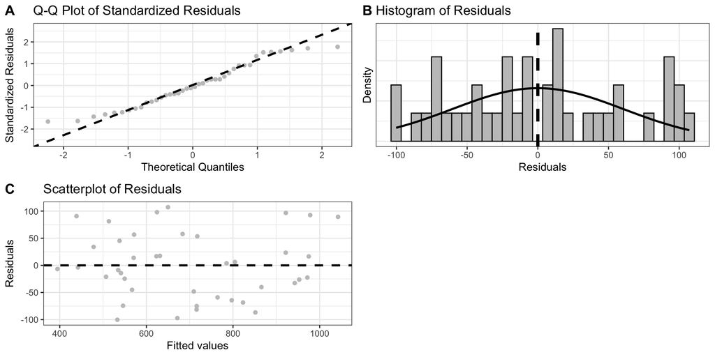

```r
overlap_reduced |> reg_check()
```

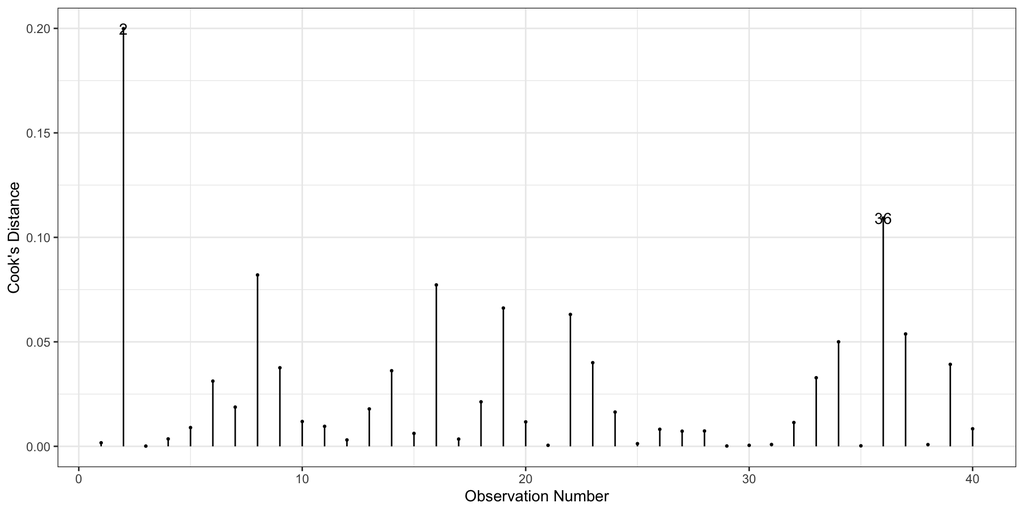

```r
overlap_reduced |> cooks()
```

- Changing the model means we should revisit its diagnostics.

## Sensitivity Analysis: Two Unusual Café Days

- The owner asks: “What if one festival day is driving the whole result?”
- To demonstrate the process, we create another **40-day demonstration copy**.
- Day 29 has exceptionally high advertising spending and unexpected sales.
- Day 40 has ordinary predictors but unexpectedly high sales.

```r
cafe_unusual <- cafe_sales |> mutate(day_id = row_number())
cafe_unusual$advertising_dollars[29] <- 220
cafe_unusual$sales_dollars[29] <-
  100 + 3 * 220 + 2 * cafe_unusual$foot_traffic[29] - 700
cafe_unusual$sales_dollars[40] <- cafe_unusual$sales_dollars[40] + 650
sensitivity_full <- lm(
  sales_dollars ~ advertising_dollars + foot_traffic,
  data = cafe_unusual
)
```

## Which Days Are Flagged?

```r
cafe_unusual <- cafe_unusual |>
  mutate(standardized_residual = rstandard(sensitivity_full),
         leverage = hatvalues(sensitivity_full),
         cooks_distance = cooks.distance(sensitivity_full),
         suspected_outlier = abs(standardized_residual) > 2.5)
cafe_unusual |>
  filter(suspected_outlier | cooks_distance > 4 / (n() - 3)) |>
  select(day_id, advertising_dollars, foot_traffic, sales_dollars,
         standardized_residual, leverage, cooks_distance)
```

| day_id | advertising_dollars | foot_traffic | sales_dollars | standardized_residual | leverage | cooks_distance |
| --- | --- | --- | --- | --- | --- | --- |
| 29 | 220.00 | 327 | 714.00 | -3.221271 | 0.5448146 | 4.139938 |
| 40 | 53.36 | 211 | 1391.29 | 4.675968 | 0.0261736 | 0.195886 |

- Distinguish residual size, leverage, and influence.

## Inspecting Influence

```r
sensitivity_full |> cooks()
```

[figure not shown]

- We know which days were changed because this is a teaching simulation.
- In real data, the diagnostics would guide questions for the café owner.

## Refit for Comparison

- Compare three situations:
  1. All 40 days.
  2. Without day 29.
  3. Without days 29 and 40.

```r
sensitivity_no29 <- lm(
  sales_dollars ~ advertising_dollars + foot_traffic,
  data = cafe_unusual |> filter(day_id != 29)
)
sensitivity_no29_40 <- lm(
  sales_dollars ~ advertising_dollars + foot_traffic,
  data = cafe_unusual |> filter(!day_id %in% c(29, 40))
)
```

## Comparing the Results

```r
sensitivity_results <- list(
  "All days" = sensitivity_full,
  "Without 29" = sensitivity_no29,
  "Without 29 and 40" = sensitivity_no29_40
) |>
  imap_dfr(function(model, label) {
    tidy(model, conf.int = TRUE) |> mutate(model = label)
  })
sensitivity_results |>
  select(model, term, estimate, conf.low, conf.high, p.value) |>
  knitr::kable(digits = 3)
```

| model | term | estimate | conf.low | conf.high | p.value |
| --- | --- | --- | --- | --- | --- |
| All days | (Intercept) | 260.168 | 108.789 | 411.548 | 0.001 |
| All days | advertising_dollars | 0.974 | -0.387 | 2.335 | 0.155 |
| All days | foot_traffic | 1.754 | 1.146 | 2.362 | 0.000 |
| Without 29 | (Intercept) | 144.670 | 0.138 | 289.202 | 0.050 |
| Without 29 | advertising_dollars | 3.205 | 1.522 | 4.888 | 0.000 |
| Without 29 | foot_traffic | 1.828 | 1.303 | 2.353 | 0.000 |
| Without 29 and 40 | (Intercept) | 124.388 | 55.217 | 193.558 | 0.001 |
| Without 29 and 40 | advertising_dollars | 3.047 | 2.243 | 3.852 | 0.000 |
| Without 29 and 40 | foot_traffic | 1.871 | 1.620 | 2.122 | 0.000 |

## Interpreting the Sensitivity Analysis

- Do the estimated associations change meaningfully?
- Do the directions, confidence intervals, or significance decisions change?
- Is the business interpretation stable across these versions?
- If results change, report that sensitivity rather than choosing the version you prefer.
- These refits are comparisons, not a justification for deleting valid observations.

## What Would We Ask the Owner?

- Was day 29’s advertising spending entered correctly?
- Did a closure or stock shortage prevent the expected sales?
- Did day 40 include a catering order that the model does not account for?
- A special event may suggest a missing explanatory variable rather than a bad observation.

## Wrap Up

- Model fit: how much sales variation is explained, and whether extra complexity helps.
- Outliers: days with unusually large residuals.
- Leverage and influence: unusual predictors and observations that affect the fit.
- Multicollinearity: explanatory variables with overlapping information.
- Sensitivity analysis: how conclusions change when we examine specific observations.
- Use diagnostics with the owner’s knowledge of the business, and document decisions.
- Next module: incorporating categorical predictors.